# Variables and conditionals

29 August 2017

In this lesson we’re going to learn more about different types of variables, which is very important in order to manipulate and query our tables (data.frame objects).

We’re going to learn:

- What types of variables there are in R (numeric, character, logical, factor)
- What are missing values and how to deal with them
- How to subset data based on conditions
- How to apply this knowledge to subset data.frame objects

We will continue using the `surveys` dataset and the `tidyverse` package:

```r
# Load the package
library(tidyverse)

# Read the data
surveys <- read_csv("data/surveys_data_short.csv")
```

## Variable types

A very useful function to get a quick summary of our data is called `summary()`:

```r
summary(surveys)
```

```
##       year       species_id            sex            hindfoot_length
##  Min.   :1977   Length:3156        Length:3156        Min.   :10.00
##  1st Qu.:1983   Class :character   Class :character   1st Qu.:20.00
##  Median :1987   Mode  :character   Mode  :character   Median :21.00
##  Mean   :1988                                         Mean   :24.69
##  3rd Qu.:1994                                         3rd Qu.:32.00
##  Max.   :2002                                         Max.   :42.00
##                                                       NA's   :194
##      weight          genus             species              taxa
##  Min.   :  7.00   Length:3156        Length:3156        Length:3156
##  1st Qu.: 23.00   Class :character   Class :character   Class :character
##  Median : 34.00   Mode  :character   Mode  :character   Mode  :character
##  Mean   : 74.44
##  3rd Qu.:138.25
##  Max.   :280.00
##
```

> In the output above, the summary looks different for the different variables. Does this make sense considering what type of variable these might be?

### Numeric and character variables

We can learn more about the contents of *data.frame* objects with the `glimpse()` function:

```r
glimpse(surveys)
```

```
## Observations: 3,156
## Variables: 8
## $ year            <int> 1978, 1978, 1978, 1978, 1978, 1978, 1979, 1979...
## $ species_id      <chr> "NL", "NL", "NL", "NL", "NL", "NL", "NL", "NL"...
## $ sex             <chr> "M", "M", "M", "M", "M", "M", "M", "M", "M", "...
## $ hindfoot_length <int> NA, 32, NA, 34, 32, NA, 33, 32, 32, 33, 30, 33...
## $ weight          <int> 218, 204, 200, 199, 197, 218, 166, 184, 206, 2...
## $ genus           <chr> "Neotoma", "Neotoma", "Neotoma", "Neotoma", "N...
## $ species         <chr> "albigula", "albigula", "albigula", "albigula"...
## $ taxa            <chr> "Rodent", "Rodent", "Rodent", "Rodent", "Roden...
```

From the output above we see that our variables are of different “types”, some are marked as `int` and others as `chr`. These stand, respectively, for “integer” and “character” and refer to the fact that these two are different types of data.

Let’s see some examples of different types of vector:

```r
# Numeric vector (integer)
x <- 1:4

# Numeric vector (with decimal points)
y <- c(0.1, 0.2, 3)

# Character vector
z <- c("cat", "dog", "horse")

class(x)
```

```
## [1] "integer"
```

```r
class(y)
```

```
## [1] "numeric"
```

```r
class(z)
```

```
## [1] "character"
```

For all practical purposes, “integer” and “numeric” vectors are identical. They are both numeric in nature and can be used in arithmetic operations. Characters, however cannot:

```r
mean(x)
```

```
## [1] 2.5
```

```r
mean(y)
```

```
## [1] 1.1
```

```r
mean(z) # does not work
```

```
## [1] NA
```

```r
x + y
```

```
## [1] 1.1 2.2 6.0 4.1
```

```r
x + z # does not work
```

```
## Error in x + z: non-numeric argument to binary operator
```

## Missing values

In the `summary()` output we obtained above, we can see there is a count of `NA` values for `hindfoot_length`.

```r
# First 10 values of hindfoot_length
surveys$hindfoot_length[1:20]
```

```
##  [1] NA 32 NA 34 32 NA 33 32 32 33 30 33 31 33 30 34 34 NA 32 34
```

These represent “missing data”, which R handles in a special way.

Let’s see some examples:

```r
# Create a vector of numbers including some NA values
x <- c(2, 3, 1, 1, NA, 10, 20)

mean(x)
```

```
## [1] NA
```

```r
sd(x)
```

```
## [1] NA
```

If we run the functions `mean()` and `sd()` on that vector, we get back `NA`! This is because the default behaviour of those functions is to not proceed with their computation if there are any missing values in the data. If we do want them to calculate the mean, excluding the missing values, we have to say so explicitly:

```r
mean(x, na.rm = TRUE)
```

```
## [1] 6.166667
```

```r
sd(x, na.rm = TRUE)
```

```
## [1] 7.574079
```

We could know about this option by looking at the help `?mean` and `?sd`.

> Calculate the mean and standard deviation of weights and hindfoot lenghts

```r
# put your code here!
```

## Conditionals

### Logical variables

There is another important variable type called a “logical”. This is a type of variable that stores the values `TRUE` and `FALSE`.

These variables are extremely useful, because we can use them to subset other vectors. See this example:

```r
# Note they are all uppercase with no quotes
logical_vector <- c(TRUE, FALSE, FALSE, TRUE)

x
```

```
## [1]  2  3  1  1 NA 10 20
```

```r
x[logical_vector]
```

```
## [1]  2  1 NA
```

Using a logical vector within `[]` returns only the values that are `TRUE`. In the above example this was not very useful, because we specified the logical values “by hand”, but consider this other case:

```r
# Create a vector
x <- c(10, 0.2, 20, -10, 5)
# Create a logical vector where values in x are above 2
above2 <- x > 2

# Original vector
x
```

```
## [1]  10.0   0.2  20.0 -10.0   5.0
```

```r
# Condition
above2
```

```
## [1]  TRUE FALSE  TRUE FALSE  TRUE
```

```r
# A subset the original vector
x[above2]
```

```
## [1] 10 20  5
```

In this case, the logical vector was constructed using a condition stipulated by us and based on the data itself.

We could easily find out how many of those cases fulfill our condition by using the `sum()` function, which for logical vectors will sum the cases containing the value `TRUE` (you can think of it as `TRUE = 1` and `FALSE = 0`):

```r
sum(above2)
```

```
## [1] 3
```

> Based on this, we can now answer our question of how many individuals weight more than 200g? Hint: first create a logical vector called `weight200` that will contain values “TRUE” and “FALSE”. Then use that vector to subset the `weight` column of the table using `[]`.

```r
# Put your code here!
```

### Conditional operators

In the example above, we managed to subset a vector based on a condition stipulated by us. There are many “operators” to perform this, listed below.

Relational operators:

- `==` is equal to
- `!=` is different from
- `%in%` is contained in
- `>` is greater than
- `>=` is greater than or equal to

Logical operators:

- `&` AND
- `|` OR

Combined, these can be used to perform very complex and customised operations.

For example, here is how we could obtain the weights for the “PH” species in our `surveys` table that have a hindfoot length greater than 25:

```r
# Make a logical operator for which the species ID is equal to "PH"
ph_hindfoot25 <- surveys$species_id == "PH" & surveys$hindfoot_length > 25

# Subset the weights based on that condition
surveys$weight[ph_hindfoot25]
```

```
##  [1] 28 33 29 32 33 33 34 34 34 32 31 29 29 42 30 34 39 31 48
```

Or a condition that evaluates cases where the hindfoot length is either above 40mm or below or equal to 10mm:

```r
surveys$hindfoot_length <= 10 | surveys$hindfoot_length > 40
```

[output not shown]

### Dealing with NA values

There are some functions that also return logical vectors. One of the most useful ones is called `is.na()`, which evaluates if the values in a vector are missing or not:

```r
x <- c(1, 2, NA, 5, 10)

# Return true if the value is missing
is.na(x)
```

```
## [1] FALSE FALSE  TRUE FALSE FALSE
```

We can “negate” a logical vector by using `!`:

```r
# Return true if the value is NOT missing
!is.na(x)
```

```
## [1]  TRUE  TRUE FALSE  TRUE  TRUE
```

This can be very handy. For example, if we wanted individuals with hindfoot length above 35mm, we obtain many `NA` values:

```r
surveys$hindfoot_length[surveys$hindfoot_length > 35]
```

```
##   [1] NA NA NA NA NA NA NA 36 36 37 NA NA 36 NA NA NA NA NA NA NA NA NA 36
##  [24] NA 38 NA NA NA NA NA NA NA NA NA NA NA NA NA 36 NA NA NA NA 37 NA NA
##  [47] NA NA NA NA NA NA NA NA NA NA NA NA NA NA NA NA NA NA 36 NA NA NA 37
##  [70] NA NA NA 36 NA NA NA NA NA NA NA NA 36 36 NA NA NA NA NA NA NA NA NA
##  [93] NA NA NA NA NA 36 NA NA NA NA NA 37 NA NA NA NA NA NA 36 42 NA NA 36
## [116] NA NA NA NA NA NA NA NA NA NA NA 39 NA NA NA NA NA NA NA NA NA NA NA
## [139] NA NA NA NA NA 38 NA NA NA NA NA 36 NA NA NA NA NA NA NA NA NA NA NA
## [162] NA NA NA NA NA NA NA NA NA NA NA NA NA NA NA NA 36 NA NA NA NA NA NA
## [185] NA NA NA 36 NA NA NA NA NA NA NA NA NA NA NA 38 NA NA NA NA NA NA NA
## [208] NA NA NA NA NA NA NA NA NA NA NA
```

We can use the `is.na()` function to solve this problem, like so:

```r
surveys$hindfoot_length[surveys$hindfoot_length > 35 & !is.na(surveys$hindfoot_length)]
```

```
##  [1] 36 36 37 36 36 38 36 37 36 37 36 36 36 36 37 36 42 36 39 38 36 36 36
## [24] 38
```

We combine the two conditions into one:

- hindfoot lengths above (`>`) 35mm

AND

- values of hindfoot length that are NOT missing (`!is.na`)

> How many values of weight are there for the species “DM” with hindfoot length above 40mm? How many values of hindfoot length are either above 40mm or below 10mm?

```r
# put your code here!
```

## Checking data variables

Knowing what kind of variables our data is composed of and whether or not there are any missing values is a **very important** step in data analysis!

There are two very convenient functions called `vis_dat()` and `vis_miss()` in the package `visdat` that can be used to get a graphical representation of data in a table. They are particularly useful for big datasets like this one:

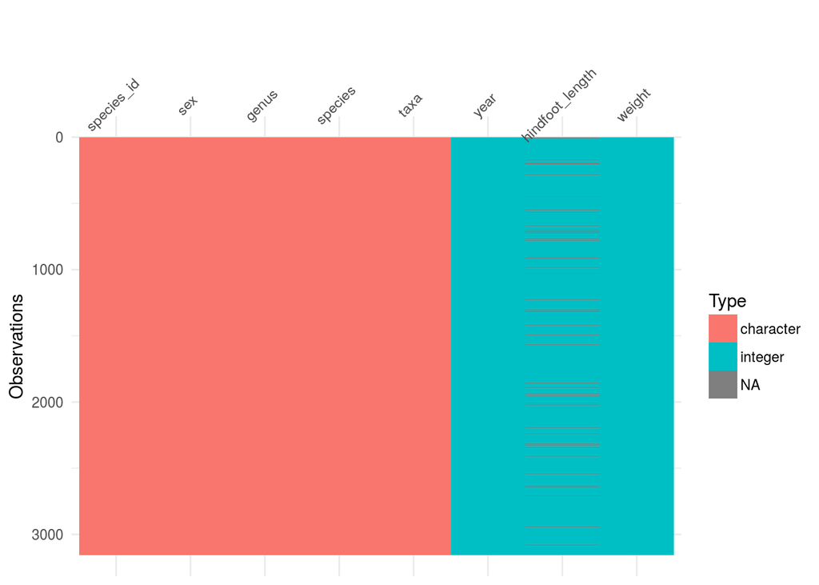

```r
library(visdat)
vis_dat(surveys)
```

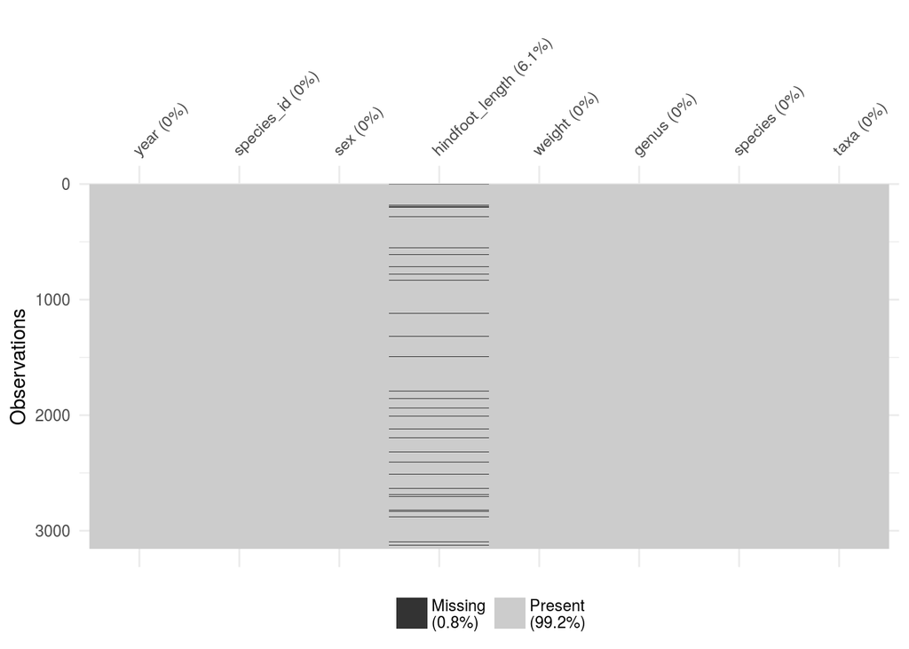

```r
vis_miss(surveys)
```

Learn more about these functions from the [package’s website](https://cran.r-project.org/web/packages/visdat/vignettes/using_visdat.html)

## factor variables

So far, we’ve seen **numeric**, **character** and **logical** vectors.

There is another type of vector, which is used to represent categorical data and is called **factor**.

We will learn later in the course how factors are important for statistical analysis. For now, consider these two vectors:

```r
char_vector <- c("low", "medium", "high", "high", "low", "low")
fctr_vector <- factor(char_vector)
```

> How are they different?

```r
char_vector
```

```
## [1] "low"    "medium" "high"   "high"   "low"    "low"
```

```r
fctr_vector
```

```
## [1] low    medium high   high   low    low
## Levels: high low medium
```

While both contain the same values, factors have a new attribute called **levels** - the unique values that occur in the vector:

```r
levels(fctr_vector) # the levels in the factor
```

```
## [1] "high"   "low"    "medium"
```

```r
nlevels(fctr_vector) # the number of levels
```

```
## [1] 3
```

Many R functions treat factors differently from character vectors. For example, the `summary()` function that we’ve already used:

```r
summary(char_vector)
```

```
##    Length     Class      Mode
##         6 character character
```

```r
summary(fctr_vector)
```

```
##   high    low medium
##      2      3      1
```

You cannot add values that are not listed in the levels of a factor:

```r
char_vector[1] <- "very low"
char_vector
```

```
## [1] "very low" "medium"   "high"     "high"     "low"      "low"
```

```r
fctr_vector[1] <- "very low"
fctr_vector
```

```
## [1] <NA>   medium high   high   low    low
## Levels: high low medium
```

And you can have levels with no observations:

```r
fctr_vector <- fctr_vector[fctr_vector != "medium"]
summary(fctr_vector)
```

```
##   high    low medium   NA's
##      2      2      0      1
```

The order of these levels is alphabetical by default, but it can be changed:

```r
fctr_vector <- factor(char_vector, levels = c("low", "medium", "high"))
levels(fctr_vector)
```

```
## [1] "low"    "medium" "high"
```

“Behind the scenes” R encodes each level of a factor as an integer number.

```r
char_vector
```

```
## [1] "very low" "medium"   "high"     "high"     "low"      "low"
```

```r
as.numeric(fctr_vector)
```

```
## [1] NA  2  3  3  1  1
```

So be careful when converting factors that look like numbers!

```r
x <- factor(c(2, 4, 5, 2, 2))
x
```

```
## [1] 2 4 5 2 2
## Levels: 2 4 5
```

```r
as.numeric(x)
```

```
## [1] 1 2 3 1 1
```

One way to solve this problem is doing the following:

```r
# First convert to a character type and then to numeric type
as.numeric(as.character(x))
```

```
## [1] 2 4 5 2 2
```

See more about factors [here](http://www.datacarpentry.org/R-ecology-lesson/02-starting-with-data.html#factors).

# Some key points to remember

- There are different types of variables in R: numeric, character, logical, factor.
- Always check what type of variables you have in a data.frame.
  - for example with `vis_dat()` from the `visdat` package
- Always check for missing values in your data.
  - for example with `vis_miss()` from the `visdat` package
- You can subset data based on certain conditions using “conditional operators” (`>`, `<`, `>=`, `<=`, `==`, `!=`, `&`, `|`).
- Factors are special kinds of categorical variables important for statistical analysis (more on Days 2 and 3 of the course).